# LBB 4

pandjibagas

8/28/2021

```r
library(tidyverse)
library(GGally)
library(MLmetrics)
library(car)
library(caret)
library(lmtest)
library(inspectdf)
library(performance)
library(e1071)
library(readxl)
library(plyr)
library(dplyr)
options(scipen = 999)
```

Pada case ini ingin melihat hubungan antara kandungan wine dengan quality berdasarkan penilaian ahli wine.

*Read data*

```r
wine <- read.csv("winequality-red.csv")
wine
```

```
##      fixed.acidity volatile.acidity citric.acid residual.sugar chlorides
## 1              7.4            0.700        0.00           1.90     0.076
## 2              7.8            0.880        0.00           2.60     0.098
## 3              7.8            0.760        0.04           2.30     0.092
## 4             11.2            0.280        0.56           1.90     0.075
## 5              7.4            0.700        0.00           1.90     0.076
## 6              7.4            0.660        0.00           1.80     0.075
## 7              7.9            0.600        0.06           1.60     0.069
## 8              7.3            0.650        0.00           1.20     0.065
## 9              7.8            0.580        0.02           2.00     0.073
## 10             7.5            0.500        0.36           6.10     0.071
## 11             6.7            0.580        0.08           1.80     0.097
## 12             7.5            0.500        0.36           6.10     0.071
## 13             5.6            0.615        0.00           1.60     0.089
## 14             7.8            0.610        0.29           1.60     0.114
```

[output cut: 4785 more lines]

*Suspect Data*

```r
glimpse(wine)
```

```
## Rows: 1,599
## Columns: 12
## $ fixed.acidity        <dbl> 7.4, 7.8, 7.8, 11.2, 7.4, 7.4, 7.9, 7.3, 7.8, 7.5…
## $ volatile.acidity     <dbl> 0.700, 0.880, 0.760, 0.280, 0.700, 0.660, 0.600, …
## $ citric.acid          <dbl> 0.00, 0.00, 0.04, 0.56, 0.00, 0.00, 0.06, 0.00, 0…
## $ residual.sugar       <dbl> 1.9, 2.6, 2.3, 1.9, 1.9, 1.8, 1.6, 1.2, 2.0, 6.1,…
## $ chlorides            <dbl> 0.076, 0.098, 0.092, 0.075, 0.076, 0.075, 0.069, …
## $ free.sulfur.dioxide  <dbl> 11, 25, 15, 17, 11, 13, 15, 15, 9, 17, 15, 17, 16…
## $ total.sulfur.dioxide <dbl> 34, 67, 54, 60, 34, 40, 59, 21, 18, 102, 65, 102,…
## $ density              <dbl> 0.9978, 0.9968, 0.9970, 0.9980, 0.9978, 0.9978, 0…
## $ pH                   <dbl> 3.51, 3.20, 3.26, 3.16, 3.51, 3.51, 3.30, 3.39, 3…
## $ sulphates            <dbl> 0.56, 0.68, 0.65, 0.58, 0.56, 0.56, 0.46, 0.47, 0…
## $ alcohol              <dbl> 9.4, 9.8, 9.8, 9.8, 9.4, 9.4, 9.4, 10.0, 9.5, 10.…
## $ quality              <int> 5, 5, 5, 6, 5, 5, 5, 7, 7, 5, 5, 5, 5, 5, 5, 5, 7…
```

```r
nrow(wine)
```

```
## [1] 1599
```

*Check NA*

```r
colSums(is.na(wine))
```

```
##        fixed.acidity     volatile.acidity          citric.acid
##                    0                    0                    0
##       residual.sugar            chlorides  free.sulfur.dioxide
##                    0                    0                    0
## total.sulfur.dioxide              density                   pH
##                    0                    0                    0
##            sulphates              alcohol              quality
##                    0                    0                    0
```

*Find outlier*

```r
summary(wine)
```

```
##  fixed.acidity   volatile.acidity  citric.acid    residual.sugar
##  Min.   : 4.60   Min.   :0.1200   Min.   :0.000   Min.   : 0.900
##  1st Qu.: 7.10   1st Qu.:0.3900   1st Qu.:0.090   1st Qu.: 1.900
##  Median : 7.90   Median :0.5200   Median :0.260   Median : 2.200
##  Mean   : 8.32   Mean   :0.5278   Mean   :0.271   Mean   : 2.539
##  3rd Qu.: 9.20   3rd Qu.:0.6400   3rd Qu.:0.420   3rd Qu.: 2.600
##  Max.   :15.90   Max.   :1.5800   Max.   :1.000   Max.   :15.500
##    chlorides       free.sulfur.dioxide total.sulfur.dioxide    density
##  Min.   :0.01200   Min.   : 1.00       Min.   :  6.00       Min.   :0.9901
##  1st Qu.:0.07000   1st Qu.: 7.00       1st Qu.: 22.00       1st Qu.:0.9956
##  Median :0.07900   Median :14.00       Median : 38.00       Median :0.9968
##  Mean   :0.08747   Mean   :15.87       Mean   : 46.47       Mean   :0.9967
##  3rd Qu.:0.09000   3rd Qu.:21.00       3rd Qu.: 62.00       3rd Qu.:0.9978
##  Max.   :0.61100   Max.   :72.00       Max.   :289.00       Max.   :1.0037
##        pH          sulphates         alcohol         quality
##  Min.   :2.740   Min.   :0.3300   Min.   : 8.40   Min.   :3.000
##  1st Qu.:3.210   1st Qu.:0.5500   1st Qu.: 9.50   1st Qu.:5.000
##  Median :3.310   Median :0.6200   Median :10.20   Median :6.000
##  Mean   :3.311   Mean   :0.6581   Mean   :10.42   Mean   :5.636
##  3rd Qu.:3.400   3rd Qu.:0.7300   3rd Qu.:11.10   3rd Qu.:6.000
##  Max.   :4.010   Max.   :2.0000   Max.   :14.90   Max.   :8.000
```

*Boxplot Before*

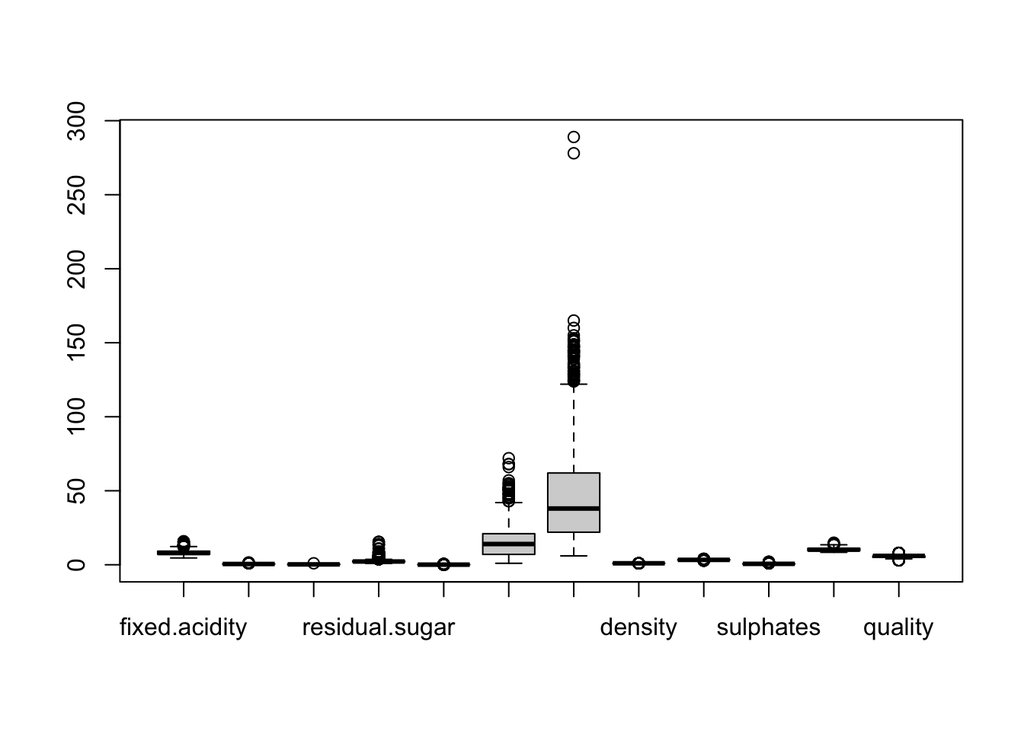

```r
boxplot(wine)
```

*Outlier iteration*

```r
#Create outlier function
outl <- function(x, na.rm = FALSE){
  qq <- quantile(x, probs = c(0.25, 0.75), na.rm = na.rm)
  iqr <- diff(qq)
  x > qq[1] - 1.5*iqr & x < qq[2] + 1.5*iqr
}

#Iteration Outliers 1
which_out1 <- colwise(outl)(wine)
wine_clean1 <- subset(wine, rowSums(which_out1) == ncol(which_out1))

#Iteration Outliers 2
which_out2 <- colwise(outl)(wine_clean1)
wine_clean2 <- subset(wine_clean1, rowSums(which_out2) == ncol(which_out2))

#Iteration Outliers 3
which_out3 <- colwise(outl)(wine_clean2)
wine_clean3 <- subset(wine_clean2, rowSums(which_out3) == ncol(which_out3))

#Iteration Outliers 4
which_out4 <- colwise(outl)(wine_clean3)
wine_clean4 <- subset(wine_clean3, rowSums(which_out4) == ncol(which_out4))

#Iteration Outliers 5
which_out5 <- colwise(outl)(wine_clean4)
wine_clean5 <- subset(wine_clean4, rowSums(which_out5) == ncol(which_out5))

nrow(wine_clean5)
```

```
## [1] 923
```

*Boxplot after*

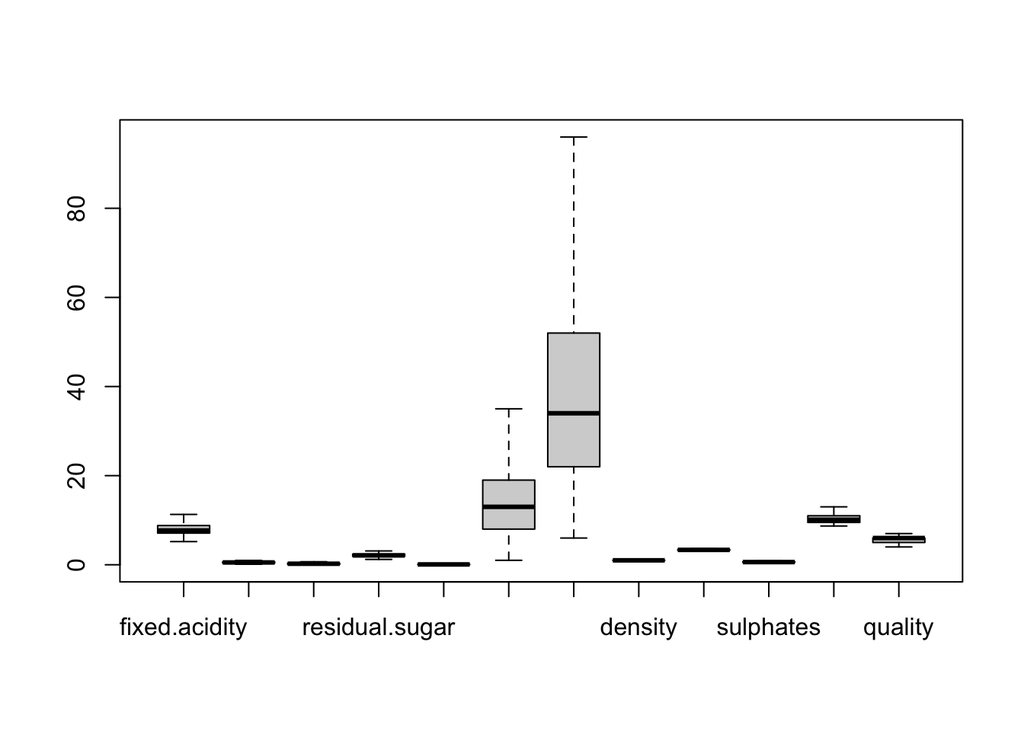

```r
boxplot(wine_clean5)
```

*Check Correlation*

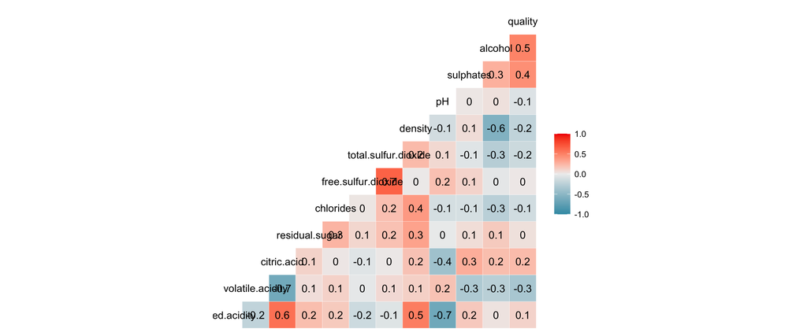

```r
ggcorr(data = wine_clean5, label = TRUE)
```

*Linierity*

```r
cor.test(wine_clean5$quality,wine_clean5$alcohol)$p.value #linier
```

```
## [1] 0.000000000000000000000000000000000000000000000000000000000378668
```

```r
cor.test(wine_clean5$quality,wine_clean5$sulphates)$p.value #linier
```

```
## [1] 0.000000000000000000000000000000000000000000092605
```

```r
cor.test(wine_clean5$quality,wine_clean5$pH)$p.value #linier
```

```
## [1] 0.03328923
```

```r
cor.test(wine_clean5$quality,wine_clean5$density)$p.value #linier
```

```
## [1] 0.000000000009770698
```

```r
cor.test(wine_clean5$quality,wine_clean5$total.sulfur.dioxide)$p.value #linier
```

```
## [1] 0.0000007509132
```

```r
cor.test(wine_clean5$quality,wine_clean5$free.sulfur.dioxide)$p.value #non linier
```

```
## [1] 0.5958058
```

```r
cor.test(wine_clean5$quality,wine_clean5$chlorides)$p.value #linier
```

```
## [1] 0.00006030588
```

```r
cor.test(wine_clean5$quality,wine_clean5$residual.sugar)$p.value #no linier
```

```
## [1] 0.1387455
```

```r
cor.test(wine_clean5$quality,wine_clean5$citric.acid)$p.value #linier
```

```
## [1] 0.00000000001237595
```

```r
cor.test(wine_clean5$quality,wine_clean5$volatile.acidity)$p.value #linier
```

```
## [1] 0.0000000000000000000000000007967186
```

```r
cor.test(wine_clean5$quality,wine_clean5$fixed.acidity)$p.value #linier
```

```
## [1] 0.0010324
```

linierity 1. alcohol 2. sulphates 3. pH 4. density 5. total.sulfur.dioxide 6. chlorides 7. citric.acid 8. volatile.acidity 9. fixed.acidity

inlinierity 1. free.sulfur.dioxide 2. residual.sugar

*Take out variable non linier*

```r
wine_clean6 <- wine_clean5 %>%
  select(-c(free.sulfur.dioxide, residual.sugar))
```

*Correlation*

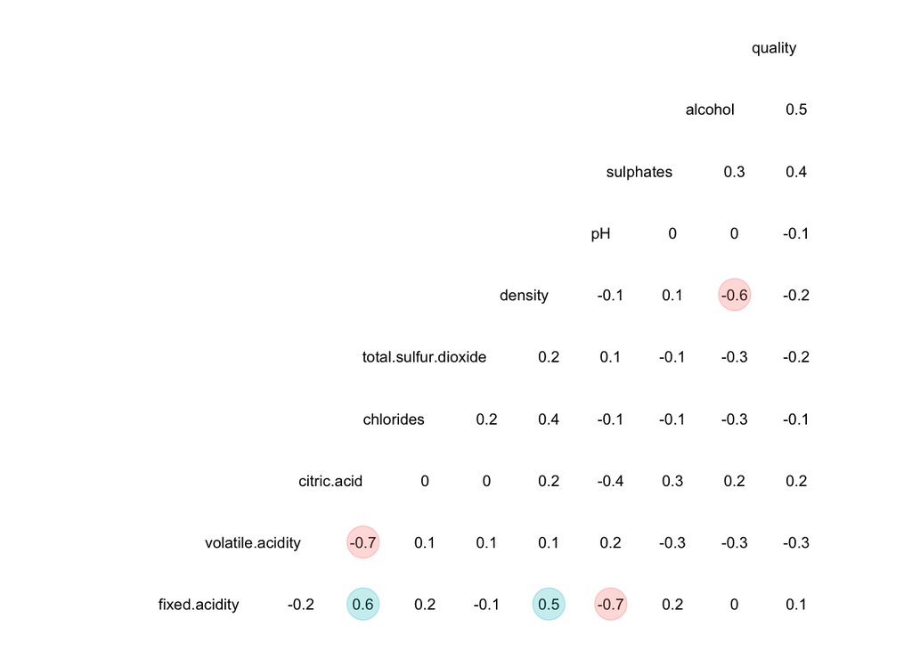

```r
ggcorr(wine_clean6, geom = "blank", label = T, label_size = 3, hjust = 1, size = 3, layout.exp = 2) +
  geom_point(size = 8, aes(color = coefficient > 0, alpha = abs(coefficient) >= 0.5)) +
  scale_alpha_manual(values = c("TRUE" = 0.25, "FALSE" = 0)) +
  guides(color = "none", alpha = "none")
```

*Splittng Model*

```r
RNGkind(sample.kind = "Rounding")
set.seed(123)

# train-test splitting
index <- sample(nrow(wine_clean6), nrow(wine_clean6)*0.75)

# sms_dtm = DocumentTermMatrix yang tidak ada labelnya
wine_train <- wine_clean6[index,]
wine_test <- wine_clean6[-index,]
```

*Step Wise Regression*

```r
# model tanpa prediktor
model_wine_none <- lm(quality ~ 1, data = wine_train)

# model dengan semua prediktor
model_wine_all <- lm(quality ~ ., data = wine_train)
```

*Backward*

```r
model_back <- step(object = model_wine_all, direction = "backward", trace = F)
summary(model_back)
```

```
##
## Call:
## lm(formula = quality ~ volatile.acidity + citric.acid + pH +
##     sulphates + alcohol, data = wine_train)
##
## Residuals:
##      Min       1Q   Median       3Q      Max
## -1.94525 -0.38253 -0.05837  0.44910  1.67451
##
## Coefficients:
##                  Estimate Std. Error t value             Pr(>|t|)
## (Intercept)       3.89418    0.71033   5.482         0.0000000591 ***
## volatile.acidity -0.95079    0.17737  -5.360         0.0000001136 ***
## citric.acid      -0.50392    0.18349  -2.746              0.00618 **
## pH               -0.63038    0.19806  -3.183              0.00153 **
## sulphates         2.13242    0.22485   9.484 < 0.0000000000000002 ***
## alcohol           0.30478    0.02397  12.713 < 0.0000000000000002 ***
## ---
## Signif. codes:  0 '***' 0.001 '**' 0.01 '*' 0.05 '.' 0.1 ' ' 1
##
## Residual standard error: 0.5708 on 686 degrees of freedom
## Multiple R-squared:  0.3927, Adjusted R-squared:  0.3882
## F-statistic:  88.7 on 5 and 686 DF,  p-value: < 0.00000000000000022
```

*Forward*

```r
model_forward <- step(object = model_wine_none,
     scope = list(lower = model_wine_none,
                  upper = model_wine_all),
     direction = "forward",
     trace = T)
```

```
## Start:  AIC=-435.07
## quality ~ 1
##
##                        Df Sum of Sq    RSS     AIC
## + alcohol               1    92.400 275.57 -633.17
## + sulphates             1    71.064 296.90 -581.56
## + volatile.acidity      1    46.661 321.30 -526.90
## + citric.acid           1    20.401 347.56 -472.54
## + density               1    19.206 348.76 -470.16
## + total.sulfur.dioxide  1    10.846 357.12 -453.77
## + chlorides             1     6.033 361.93 -444.51
## + fixed.acidity         1     4.253 363.71 -441.11
## + pH                    1     2.614 365.35 -438.00
## <none>                              367.97 -435.07
##
## Step:  AIC=-633.17
## quality ~ alcohol
##
##                        Df Sum of Sq    RSS     AIC
## + sulphates             1    38.848 236.72 -736.32
## + volatile.acidity      1    21.235 254.33 -686.66
## + citric.acid           1     6.173 269.39 -646.84
## + pH                    1     3.224 272.34 -639.31
## + fixed.acidity         1     2.676 272.89 -637.92
## + density               1     1.637 273.93 -635.29
## <none>                              275.56 -633.17
## + total.sulfur.dioxide  1     0.402 275.16 -632.18
## + chlorides             1     0.003 275.56 -631.18
##
## Step:  AIC=-736.32
## quality ~ alcohol + sulphates
##
##                        Df Sum of Sq    RSS     AIC
## + volatile.acidity      1    9.0517 227.66 -761.30
## + pH                    1    3.8196 232.90 -745.58
## + citric.acid           1    1.1222 235.59 -737.61
## + fixed.acidity         1    0.7406 235.98 -736.49
## <none>                              236.72 -736.32
## + total.sulfur.dioxide  1    0.5934 236.12 -736.06
## + chlorides             1    0.0605 236.66 -734.50
```

[output cut: 19 more lines]

```
## <none>                              225.94 -764.57
## + fixed.acidity         1   0.62262 225.32 -764.48
## + total.sulfur.dioxide  1   0.35362 225.59 -763.65
## + density               1   0.11266 225.83 -762.91
## + chlorides             1   0.03026 225.91 -762.66
##
## Step:  AIC=-770.14
## quality ~ alcohol + sulphates + volatile.acidity + pH + citric.acid
##
##                        Df Sum of Sq    RSS     AIC
## <none>                              223.48 -770.14
## + density               1  0.226214 223.26 -768.84
## + total.sulfur.dioxide  1  0.152620 223.33 -768.61
## + chlorides             1  0.145111 223.34 -768.58
## + fixed.acidity         1  0.005148 223.48 -768.15
```

```r
summary(model_forward)
```

```
##
## Call:
## lm(formula = quality ~ alcohol + sulphates + volatile.acidity +
##     pH + citric.acid, data = wine_train)
##
## Residuals:
##      Min       1Q   Median       3Q      Max
## -1.94525 -0.38253 -0.05837  0.44910  1.67451
##
## Coefficients:
##                  Estimate Std. Error t value             Pr(>|t|)
## (Intercept)       3.89418    0.71033   5.482         0.0000000591 ***
## alcohol           0.30478    0.02397  12.713 < 0.0000000000000002 ***
## sulphates         2.13242    0.22485   9.484 < 0.0000000000000002 ***
## volatile.acidity -0.95079    0.17737  -5.360         0.0000001136 ***
## pH               -0.63038    0.19806  -3.183              0.00153 **
## citric.acid      -0.50392    0.18349  -2.746              0.00618 **
## ---
## Signif. codes:  0 '***' 0.001 '**' 0.01 '*' 0.05 '.' 0.1 ' ' 1
##
## Residual standard error: 0.5708 on 686 degrees of freedom
## Multiple R-squared:  0.3927, Adjusted R-squared:  0.3882
## F-statistic:  88.7 on 5 and 686 DF,  p-value: < 0.00000000000000022
```

*Both*

```r
model_both <- step(object = model_wine_none,
     scope = list(lower = model_wine_none,
                  upper = model_wine_all),
     direction = "both",
     trace = T)
```

```
## Start:  AIC=-435.07
## quality ~ 1
##
##                        Df Sum of Sq    RSS     AIC
## + alcohol               1    92.400 275.57 -633.17
## + sulphates             1    71.064 296.90 -581.56
## + volatile.acidity      1    46.661 321.30 -526.90
## + citric.acid           1    20.401 347.56 -472.54
## + density               1    19.206 348.76 -470.16
## + total.sulfur.dioxide  1    10.846 357.12 -453.77
## + chlorides             1     6.033 361.93 -444.51
## + fixed.acidity         1     4.253 363.71 -441.11
## + pH                    1     2.614 365.35 -438.00
## <none>                              367.97 -435.07
##
## Step:  AIC=-633.17
## quality ~ alcohol
##
##                        Df Sum of Sq    RSS     AIC
## + sulphates             1    38.848 236.72 -736.32
## + volatile.acidity      1    21.235 254.33 -686.66
## + citric.acid           1     6.173 269.39 -646.84
## + pH                    1     3.224 272.34 -639.31
## + fixed.acidity         1     2.676 272.89 -637.92
## + density               1     1.637 273.93 -635.29
## <none>                              275.57 -633.17
## + total.sulfur.dioxide  1     0.402 275.16 -632.18
## + chlorides             1     0.003 275.56 -631.18
## - alcohol               1    92.400 367.97 -435.07
##
## Step:  AIC=-736.32
## quality ~ alcohol + sulphates
##
##                        Df Sum of Sq    RSS     AIC
## + volatile.acidity      1     9.052 227.66 -761.30
## + pH                    1     3.820 232.90 -745.58
## + citric.acid           1     1.122 235.59 -737.61
## + fixed.acidity         1     0.741 235.98 -736.49
## <none>                              236.72 -736.32
## + total.sulfur.dioxide  1     0.593 236.12 -736.06
```

[output cut: 34 more lines]

```
##
## Step:  AIC=-770.14
## quality ~ alcohol + sulphates + volatile.acidity + pH + citric.acid
##
##                        Df Sum of Sq    RSS     AIC
## <none>                              223.48 -770.14
## + density               1     0.226 223.26 -768.84
## + total.sulfur.dioxide  1     0.153 223.33 -768.61
## + chlorides             1     0.145 223.34 -768.58
## + fixed.acidity         1     0.005 223.48 -768.15
## - citric.acid           1     2.457 225.94 -764.57
## - pH                    1     3.300 226.78 -761.99
## - volatile.acidity      1     9.361 232.84 -743.74
## - sulphates             1    29.301 252.78 -686.88
## - alcohol               1    52.655 276.14 -625.73
```

```r
summary(model_both)
```

```
##
## Call:
## lm(formula = quality ~ alcohol + sulphates + volatile.acidity +
##     pH + citric.acid, data = wine_train)
##
## Residuals:
##      Min       1Q   Median       3Q      Max
## -1.94525 -0.38253 -0.05837  0.44910  1.67451
##
## Coefficients:
##                  Estimate Std. Error t value             Pr(>|t|)
## (Intercept)       3.89418    0.71033   5.482         0.0000000591 ***
## alcohol           0.30478    0.02397  12.713 < 0.0000000000000002 ***
## sulphates         2.13242    0.22485   9.484 < 0.0000000000000002 ***
## volatile.acidity -0.95079    0.17737  -5.360         0.0000001136 ***
## pH               -0.63038    0.19806  -3.183              0.00153 **
## citric.acid      -0.50392    0.18349  -2.746              0.00618 **
## ---
## Signif. codes:  0 '***' 0.001 '**' 0.01 '*' 0.05 '.' 0.1 ' ' 1
##
## Residual standard error: 0.5708 on 686 degrees of freedom
## Multiple R-squared:  0.3927, Adjusted R-squared:  0.3882
## F-statistic:  88.7 on 5 and 686 DF,  p-value: < 0.00000000000000022
```

*Compare*

```r
compare_performance(model_back, model_forward, model_both)
```

```
## # Comparison of Model Performance Indices
##
## Name          | Model |      AIC |      BIC |    R2 | R2 (adj.) |  RMSE | Sigma
## -------------------------------------------------------------------------------
## model_back    |    lm | 1195.676 | 1227.453 | 0.393 |     0.388 | 0.568 | 0.571
## model_forward |    lm | 1195.676 | 1227.453 | 0.393 |     0.388 | 0.568 | 0.571
## model_both    |    lm | 1195.676 | 1227.453 | 0.393 |     0.388 | 0.568 | 0.571
```

*Predict*

```r
wine_predict <- predict(model_both, newdata = wine_test, level = 0.95)
```

*Predict VS Actual*

```r
wine_test$predict <- wine_predict

wine_test %>%
  mutate(quality_flag = ifelse(quality > 6, "good", "bad"),
         predict_flag = ifelse(predict > 6, "good", "bad")) %>%
  select(quality_flag, predict_flag) %>%
  table()
```

```
##             predict_flag
## quality_flag bad good
##         bad  181   34
##         good   2   14
```

*Normality*

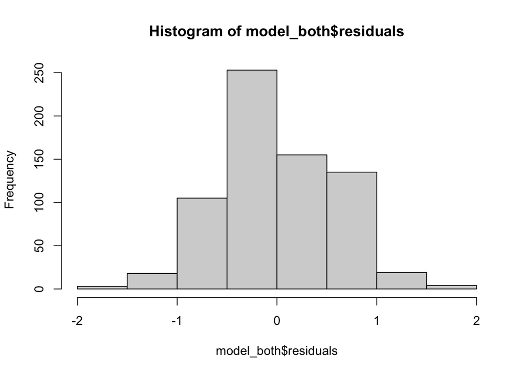

```r
hist(model_both$residuals)
```

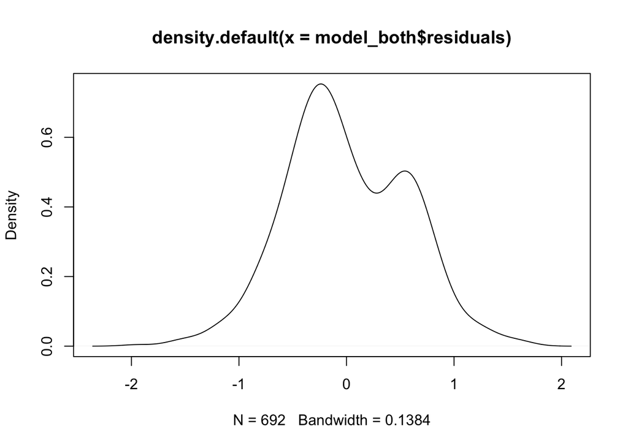

```r
plot(density(model_both$residuals))
```

```r
shapiro.test(model_both$residuals)
```

```
##
##  Shapiro-Wilk normality test
##
## data:  model_both$residuals
## W = 0.9925, p-value = 0.00148
```

Kesimpulan : tidak terdistribusi normal

*Homoscedasticity*

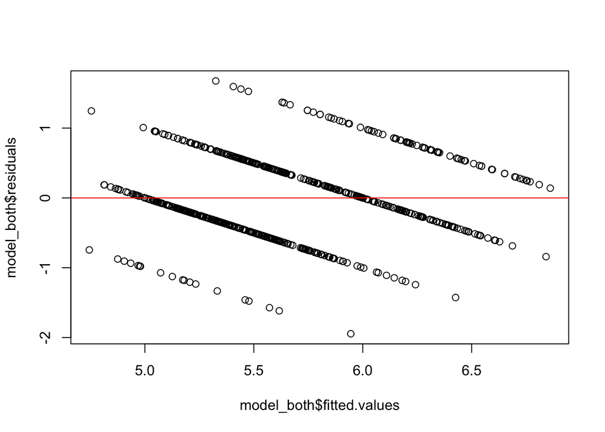

```r
plot(model_both$fitted.values, model_both$residuals)
abline(h = 0, col = "red")
```

```r
bptest(model_both)
```

```
##
##  studentized Breusch-Pagan test
##
## data:  model_both
## BP = 1.1424, df = 5, p-value = 0.9503
```

*Multicolinerity*

```r
vif(model_both)
```

```
##          alcohol        sulphates volatile.acidity               pH
##         1.114592         1.180623         1.809674         1.238258
##      citric.acid
##         2.043909
```

Kesimpulan : semua data tidak multicolinierity

#Kesimpulan

Variable target pada kasus ini adalah quality karena outputnya adalah memprediksi hasil quality wine dari variable predictor. Dari exploratory data terdapat 9 variable yang linier dari 11 variable dengan korelasi tertinggi terdapat pada variable alcohol sebesar 0.5. Interpretasinya dari model adalah 40% hasil quality of wine dapat dihasilkan dari hubungan dengan variable terpilih yang sisanya digambarkan oleh variable lainnya.

Secara model prediksi dari data test sebesar 25% kita melakukan klasifikasi dri hasil prediksi & actual dengan threshold jika quality > 6 adalah “good” wine dan sebaliknya “bad”. Hal ini dilakukan karena hasil dari prediksi adalah numerik continue sedangkan actual tidak. Dihasilkan bahwa dari total data test 231 terdapat 34 data false positive dan 2 data false negative yang sisanya sesuai dengan actual, jika dipersentasekan terdapat 15% data prediksi yang tidak sesuai. Maka disimpulkan model prediksi dari data train memiliki 15% error yang secara standar hanya 5% dari data.